# Practical Machine Learning

Johan van der Watt

2 June 2016

## Synopsis

One thing that people regularly do is quantify how much of a particular activity they do, but they rarely quantify how well they do it. In this project, the goal is to use data from accelerometers on the belt, forearm, arm, and dumbell of 6 participants to predict the manner in which they did the exercise.

The data from this project is sourced from http://groupware.les.inf.puc-rio.br/har and it includes the observed manner in which they did the exercise in a variable called **classe**

This project compared a number of models on the training data and concluded that the Random Forest algorithm provided the most accurate predictions.

## Loading the data

Training data is sourced from https://d396qusza40orc.cloudfront.net/predmachlearn/pml-training.csv

```r
#Check to see if file has been downloaded in \data sub folder. If not, read directly from URL
fTrainLocal <- paste(getwd(),"/data/pml-training.csv",sep="")
fTrainURL <- "https://d396qusza40orc.cloudfront.net/predmachlearn/pml-training.csv"

if (file.exists(fTrainLocal))
    {raw.train <- read_csv(fTrainLocal)} else
    {raw.train <- read_csv(fTrainURL)}
```

## Preparing the data

We will have a quick look at the data to see if we need to keep all the variables, rename columns or manipulate values if required and gather any information we can use for our modelling.

First let’s see how many rows and columns we have.

```r
dim(raw.train)
```

```
## [1] 19622   160
```

That’s a large number of rows (which means we can happily create a model building, as well as a validation data set) but also a very large number of variables. The following R tools have been used to investigate the dataset, but the output has been hidden (using `results='hide'` in r chunk options) to keep this document to a reasonable size.  
’

```r
# Look at variable names, classes and first few values
str(raw.train)
# Look at variable scale, range, NAs or 0's, etc.
summary(raw.train)
# Look at the data in a table format to get a better feel for it
View(raw.train[1000:1500,]) #just pick 500 rows not at start or end
```

We note that

- The **first column** doesn’t have a name. The data in this column indicates that it’s just a sequence number for the reords. *(we’ll give this column a name, but will exclude it when we train our model)*
- columns 2 through 7 (**user_name, raw_timestamp_part_1, raw_timestamp_part_2, cvtd_timestamp, new_window, num_window**) are describing the data row but are not valuable as predictive features *(we’ll exclude these when we train our model)*
- The **classe** variable (the observed outcome variable) is the last column and its class character, *(we will remember this for our modelling and also change it’s class to a factor)*
- A number of variables have NA values *(we will investigate these further)*
- There are a large numer of calculated variable names (min, max, avg, etc.). Looking at the datasource (website), we learn that 96 features have been derived:

  “For the Euler angles of each of the four sensors we calculated eight features: **mean, variance, standard deviation, max, min, amplitude, kurtosis and skewness**, generating in total 96 derived feature sets.” - the Euler angles are “roll”, “pitch” and “yaw”.

  There are actually four additional variance variables related to acceleration that falls in this same category. *(we will remove the 96 +4 variables that relate to calculated features as these are actually part of the original scientists’ model. Our model will be built on the raw data only)*

```r
#Let's first remove the columns for those 8 calculated features. We'll create a new data.frame
pre.train <- dplyr::select (raw.train, -starts_with("avg_"), -starts_with("var_"),
                          -starts_with("stddev_"),-starts_with("max_"),
                          -starts_with("min_"),-starts_with("amplitude_"),
                          -starts_with("kurtosis_"),-starts_with("skewness_"))

#Let's give the first column a name
colnames(pre.train)[1]<-"sequence_number"

#And make the outcome variable a factor
pre.train$classe <- as.factor(pre.train$classe)

# Now let's get a feel for those NA values
c(nrow(pre.train),sum(!complete.cases(pre.train)))
```

```
## [1] 19622     1
```

This indicates that there’s only 1 row out of 19,622 that does not have a full set of variable values. This is insignificant so we will discard the row instead of trying to impute any missing values.

```r
#discard the incomplete row
pre.train<-pre.train[complete.cases(pre.train),]
dim(pre.train)
```

```
## [1] 19621    60
```

## Create building and validation data

We noted a large number of rows (19621) in our prepared dataset. This means we have the luxury of splitting this dataset into a **building** data set (which we will use to build our predictive model) and a **validation** data set which we can use to validate our model to determine how accurate it is on previously unseen data (not used t train with).

We’re setting a seed variable that we will use prior to any random selection methods to make this project reproducible.

```r
seed <- 828 # this seed variable will be used later
```

Create the building and validation data sets

```r
# set the seed
set.seed(seed)

#Include 75% of the prepared dataset in the model building data set, and 25% in the validation set
inBuild<-createDataPartition(pre.train$classe,p=0.75,list = FALSE)
building <- pre.train[inBuild,]
validation <- pre.train[-inBuild,]

#How many records in our building dataset?
nrow(building)
```

```
## [1] 14718
```

```r
#And how many records in each classe?
table(building$classe)
```

```
##
##    A    B    C    D    E
## 4185 2848 2567 2412 2706
```

The above shows that we have a large number of records in each classe which is good for training our model.

# Exploring the data

The goal of this section is to learn something about the distribution, central tendency and spread of each variable.This will help us decide on the type of model to train.

```r
# The DescTools package is very handy for this
library(DescTools)

#set options to make output more readable
options(digits=3, scipen = 1000)

#Describe and optionally plot variable detials
Desc(building[,8:60], plotit=FALSE) #set plotit to TRUE for insightful charts
```

The above will describe all the training variables as well as the outcome variable. This output has been hidden from this repoirt, but we note that

- a number of variables are almost normally distributed, e.g. **total_accel_forearm**
- a number of variabes have a double gaussian distribution curve, e.g. **accel_belt_z**
- a number of variables are skewed, e.g. **magnet_belt_y**

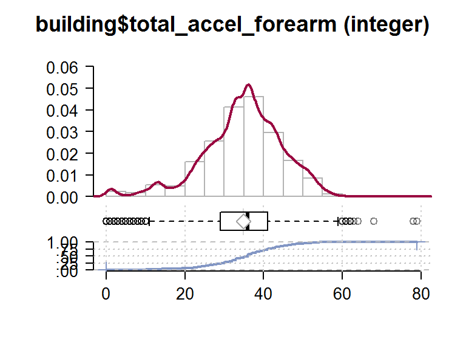

```r
Desc(building$total_accel_forearm, plotit=TRUE)
```

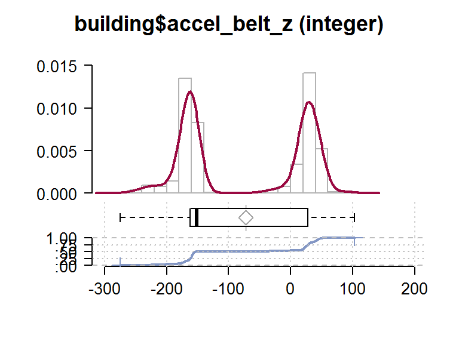

```r
Desc(building$accel_belt_z, plotit=TRUE)
```

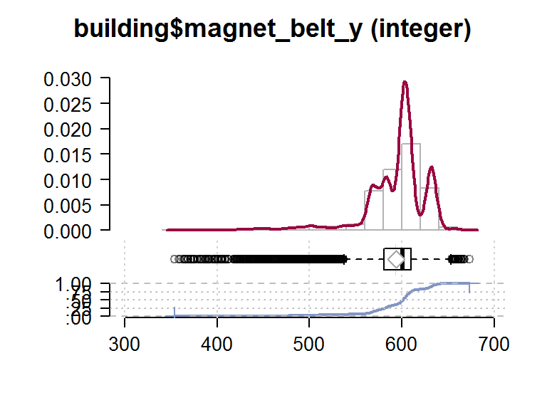

```r
Desc(building$magnet_belt_y, plotit=TRUE)
```

## Training the model

Based on the large number of variables and the different characterisrtics of them, three linear and non-linear models will be trained and then compared. Data will be standardised (centred and scaled) and normalised for models where it is appropriate.

The model types selected for training are

- Linear Discriminant Analysis (LDA) (**linear**)
- k-Nearest Neighbors (KNN) (**non-linear**)
- Random Forest (RF) (**complex non-linear**)

k-fold **cross-validation** is done (with the number of folds set to 5) to calculate the estimated accuracy of the models.

The same seed will be set before each model is tained to ensure that random sampling is consistent for all the models.

```r
#set up k-fold cross validation to measure accuracy

trainControl <- trainControl(method="cv", number=5)
metric <- "Accuracy"

# The training dataset contains only the predictor and outcomce variables identified
training<-building[,8:60]

# LDA
set.seed(seed)
fit.lda <- train(classe~., data=training, method="lda", preProc=c("center", "scale"),metric=metric, trControl=trainControl)
# KNN
set.seed(seed)
fit.knn <- train(classe~., data=training, method="knn", preProc=c("center", "scale"), metric=metric, trControl=trainControl)
# RF
set.seed(seed)
fit.rf <- train(classe~., data=training, method="rf", prox=TRUE, metric=metric, trControl=trainControl)
```

Now we compare the results of these models ot pick our best model. The **resamples** function gathers the results of the 5 k-fold cross-validation samples for each model.

```r
# summarize accuracy of models
results <- resamples(list(LDA=fit.lda, KNN=fit.knn, RF=fit.rf))
summary(results)
```

```
##
## Call:
## summary.resamples(object = results)
##
## Models: LDA, KNN, RF
## Number of resamples: 5
##
## Accuracy
##      Min. 1st Qu. Median  Mean 3rd Qu.  Max. NA's
## LDA 0.689   0.702  0.704 0.704   0.708 0.718    0
## KNN 0.958   0.958  0.959 0.959   0.960 0.962    0
## RF  0.988   0.991  0.991 0.991   0.991 0.993    0
##
## Kappa
##      Min. 1st Qu. Median  Mean 3rd Qu.  Max. NA's
## LDA 0.607   0.622  0.626 0.626   0.630 0.643    0
## KNN 0.947   0.947  0.948 0.948   0.949 0.952    0
## RF  0.985   0.988  0.988 0.988   0.988 0.991    0
```

The above indicates that the Random Forest (RF) model outperformed the other models with accuracy as the metric. Let’s look at the final model, with an average accuracy of 99.1%.

```r
fit.rf$finalModel
```

```
##
## Call:
##  randomForest(x = x, y = y, mtry = param$mtry, proximity = TRUE)
##                Type of random forest: classification
##                      Number of trees: 500
## No. of variables tried at each split: 27
##
##         OOB estimate of  error rate: 0.73%
## Confusion matrix:
##      A    B    C    D    E class.error
## A 4181    3    1    0    0    0.000956
## B   21 2821    6    0    0    0.009480
## C    0   13 2545    9    0    0.008570
## D    0    0   39 2370    3    0.017413
## E    0    1    3    8 2694    0.004435
```

## Validation

Now that we have picked the best model, let’s try it out on previously unseen (by training algorithm) data, namely our validation dataset that we kept aside earlier

```r
# try our winning model on validation dataset (without the outcome variable)
pred.validation <- predict(fit.rf, validation[,-60])

#and let's see how we did
confusionMatrix(pred.validation, validation$classe)
```

```
## Confusion Matrix and Statistics
##
##           Reference
## Prediction    A    B    C    D    E
##          A 1390    4    0    0    0
##          B    3  943    4    0    1
##          C    0    2  848   11    0
##          D    0    0    3  793    3
##          E    1    0    0    0  897
##
## Overall Statistics
##
##                Accuracy : 0.993
##                  95% CI : (0.991, 0.996)
##     No Information Rate : 0.284
##     P-Value [Acc > NIR] : <0.0000000000000002
##
##                   Kappa : 0.992
##  Mcnemar's Test P-Value : NA
##
## Statistics by Class:
##
##                      Class: A Class: B Class: C Class: D Class: E
## Sensitivity             0.997    0.994    0.992    0.986    0.996
## Specificity             0.999    0.998    0.997    0.999    1.000
## Pos Pred Value          0.997    0.992    0.985    0.992    0.999
## Neg Pred Value          0.999    0.998    0.998    0.997    0.999
## Prevalence              0.284    0.194    0.174    0.164    0.184
## Detection Rate          0.283    0.192    0.173    0.162    0.183
## Detection Prevalence    0.284    0.194    0.176    0.163    0.183
## Balanced Accuracy       0.998    0.996    0.994    0.992    0.998
```

Our accuracy on the validation data is 99.3% with a 95% confidence interval of 99.1%-99.6%. This is pretty high and we are confident that our model will fare well.

## Prediction

We will now use our model to predict the data in the test set for this project. Let’s first load the data.

Test data is sourced from https://d396qusza40orc.cloudfront.net/predmachlearn/pml-testing.csv

```r
#Check to see if file has been downloaded in \data sub folder. If not, read directly from URL
fTestLocal <- paste(getwd(),"/data/pml-testing.csv",sep="")
fTestURL <- "https://d396qusza40orc.cloudfront.net/predmachlearn/pml-testing.csv"

if (file.exists(fTestLocal))
    {testing <- read_csv(fTestLocal)} else
    {testing <- read_csv(fTestURL)}
```

And without peeking at the data, let’s predict the outcome with our best (RF) trained model

```r
# predict testing data outcomes
pred.test <- predict(fit.rf, testing)

#Let's see the outcomes
table(pred.test)
```

```
## pred.test
## A B C D E
## 7 8 1 1 3
```